# Improving a bad chart

Thomas Weissensteiner

2024-10-27

**My scripts:**

- rendered html versions: [Rpubs/thomas-weissensteiner](https://rpubs.com/thomas-weissensteiner)
- .rmd files with executable code chunks: www.github.com/thomas-weissensteiner/portfolio/tree/main/

**About myself:** www.linkedin.com/in/ThomasWs-Mopfair

### 1. Background and a “bad” chart

“Wonderful Wednesdays” are a monthly webinar organised by the Visualisation Special Interest Group of Statisticians in the Pharmaceutical Industry ([PSI](https://psiweb.org/)).  
This script was written for the VIS-SIG Wonderful Wednesdays challenge 13 Nov 24 (https://github.com/VIS-SIG/Wonderful-Wednesdays/tree/master/data/2024/2024-10-09). The task involved summary data of a randomized study, and consisted of suggesting a better visualisation than the example chart.

```r
# - r libraries and data                             - #

library(dplyr)        # version 1.1.4  # general grammar
library(purrr)        # version 1.0.2  # set_names, list_rbind
library(tidyr)        # version 1.3.1  # pivot_longer, pivot_wider
library(ggpubr)       # version 0.6.0, includes ggplot2 3.4.0 # stat_compare_means, ggtexttable, ggarrange
library(ggrepel)      # version 0.9.6  # geom_text_repel
library(RColorBrewer) # versin 1.1-3   # scale_color_brewer (optional)

exampleData <- read.csv("https://raw.githubusercontent.com/VIS-SIG/Wonderful-Wednesdays/refs/heads/master/data/2024/2024-10-09/WW_Nov2024.csv")

exampleData
```

```
##   TREATMENT  X1  X2  X3  X4  X5  X6   X7
## 1         1 6.2 5.7 5.2 4.8 4.1 6.0  5.2
## 2         2 2.2 3.8 4.0 4.2 4.7 2.3  2.8
## 3         3 5.5 4.6 4.2 5.3 5.4 6.7  4.3
## 4         4 6.1 6.4 7.3 7.2 8.0 5.8  5.1
## 5         5 7.0 7.2 8.3 8.5 9.3 8.1  6.4
## 6         6 8.5 8.1 9.0 8.3 7.4 6.3  5.6
## 7         7 2.5 2.1 1.8 2.3 4.1 9.4 10.0
## 8         8 7.6 8.1 7.4 7.9 6.1 5.5  5.7
```

Additional information provided for the challenge:

- Data were from a randomized study comparing 8 treatments/interventions
- Subjects were followed up at 7 visits, with the intervention given between visits 5 and 6
- The dataset contained mean scores by treatment and visit
- Endpoint was the Disease Index Score
- A “bad” chart:

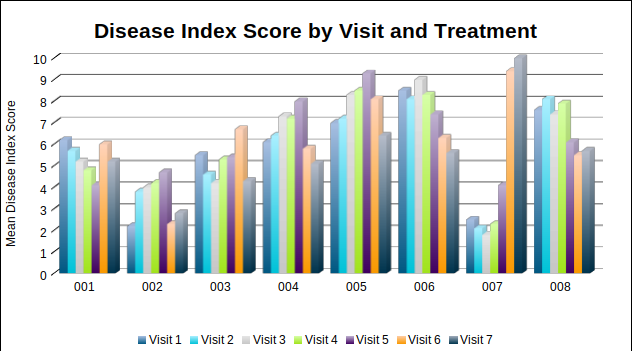

### 2. Suggestions for improved visualisations

### 2.1. Disease activiy across consecutive visits, and before and after the intervention

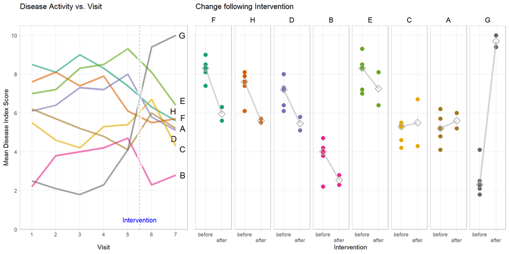

```r
# - Chunk_1                                                            - #
# - Requires R-libraries and object exampleData (r libraries and data) - #

exampleData_int <-
  exampleData %>%
  set_names(
    "Treatment",
    paste(c(1:7), sep = ", " )
    ) %>%

# Add a column with differences between the medians of disease activity at visits before and after the intervention
  mutate(
    Change_intervention =
      apply(., 1, function(row) {
        median(row[c("6", "7")]) -
        median(row[c("1", "2", "3", "4", "5")])
        }
      )
    ) %>%

# Optional: replace treatment numbers with letters, to differentiate from the index for visits
  mutate(
    Treatment = LETTERS[1:8]
  ) %>%

# Re-arrange dataframe
  arrange (Change_intervention) %>%

  pivot_longer(
      cols = paste(1:7),
      names_to = "Visit",
      values_to = "Mean_Disease_Index"
      ) %>%
  mutate(.after = Visit,
    Visit = as.numeric(Visit),
    Intervention = ordered(
      rep(
        c(rep("before", 5), rep("after", 2)),
        8),
      levels = c("before", "after")
      ),
   Treatment = factor(
     Treatment,
     levels = unique(Treatment)
     )
    )


# Plot

p_visits <-
  exampleData_int %>%
  mutate(facet_strip = "") %>%   # Empty facet label for aligning the y-axis scales of the two subplots
    ggplot(
    aes(
      x = Visit,
      y = Mean_Disease_Index,
      color = Treatment
      )
    ) +
  scale_color_brewer(palette="Dark2") +
  geom_text_repel(
    data = subset(
      exampleData_int,
      Visit == "7" & (Treatment %in% LETTERS[1:8] )
      ),
    aes(label = Treatment),
    nudge_x = 0.5,
    color = "black",
    size = 5
  ) +
  facet_grid(.
      ~ facet_strip
      ) +
  geom_line (lwd = 1.5, alpha = 0.6) +
  scale_x_continuous(
    breaks = 1:7,
    minor_breaks = NULL,
    expand = c(0, 0), limits = c(0.5, 7.5),
    labels = c(paste(1:6), "7\n")
    ) +
  scale_y_continuous(
    breaks = seq(0, 10, 2),
    minor_breaks = NULL,
    expand = c(0, 0), limits = c(0, 10.5)
    ) +
  geom_vline(
    aes( xintercept = 5.5),
    linetype = "dashed",
    col = "blue"
    ) +
  annotate(
    "rect",
    xmin = 5.4, xmax = 5.6,
    ymin = -Inf, ymax=Inf,
    fill="white", alpha=0.6) +
  annotate(
    "text",
    x = 5.5, y = 0.5,
    label = "Intervention",
    size = 4,
    color = "blue"
    ) +
  theme_light() +
  theme(
    legend.position = "none",
    strip.background = element_blank(),
    strip.text.x=element_text(
      colour="black",
      size = 12
      ),
    ) +
  labs(
    y = "Mean Disease Index Score",
    title = "Disease Activity vs. Visit",
    vjust = -0.1
    )


p_intervention <-
  exampleData_int %>%
  ggplot(
    aes(
      x = Intervention,
      y = Mean_Disease_Index,
      color = Treatment,
      )
    ) +
  scale_color_brewer(palette="Dark2") +
  scale_y_continuous(         # Same for both subplots
    breaks = seq(0, 10, 2),
    minor_breaks = NULL,
    expand = c(0, 0),
    limits = c(0, 10.5)
    ) +
  scale_x_discrete(
    labels = c("before", "\nafter")
    )+
  facet_grid(.
      ~ Treatment
      ) +
  geom_point(
    size = 3
    ) +
  stat_summary(
    fun = median,
    shape = 5,
    size = 0.8,
    color = "darkgrey"
    ) +
  stat_summary(
    fun = median,
    group = 1,
    geom = "path",
    color = "darkgrey", alpha = 0.5,
    lwd = 1.3
    ) +
  theme_light() +
  theme(
    axis.title.y = element_blank(),
    axis.text.y = element_blank(),
    strip.background = element_blank(),
    strip.text.x=element_text(
      colour="black",
      size = 12
      ),
    legend.position = "none"
    ) +
  labs(
    title = "Change following Intervention",
    vjust = -0.1
    )

ggarrange(
   p_visits,
   p_intervention,
   ncol = 2,
   widths = c(0.6, 1)
   )
```

The original data used numbers for indexing visits (X1-X7) as well as treatment groups (1-8). For better distinction, I changed the names of the treatment groups to upper case letters (A = 1, B = 2, … H = 8).

*“Mean Disease Index vs Visit” (left subplot)*  
Disease activity varied widely between groups and visits, in the periods before and after the intervention. There was a sharp rise in disease activity in group “G” after the intervention, and a notable drop in group “F”. However, both of these trends seemed to have started already at visits 4 and 5.

*“Change following Intervention” (right subplot)*  
Nevertheless, I added a summary of mean disease index scores before and after intervention. My assumption was that visits 1-5 were meant to establish a baseline value, to which levels at visits 6 and 7 were to be compared. Median values of the mean disease indices before and after intervention are shown as grey open diamonds, their changes are highlighted by grey lines. Treatment groups are shown left to right in order of greatest decrease (group “F”, left) to greatest the increase (group “G”, right).

### 2.2. Disease activiy vs. time of visit, highlighting disease index target range

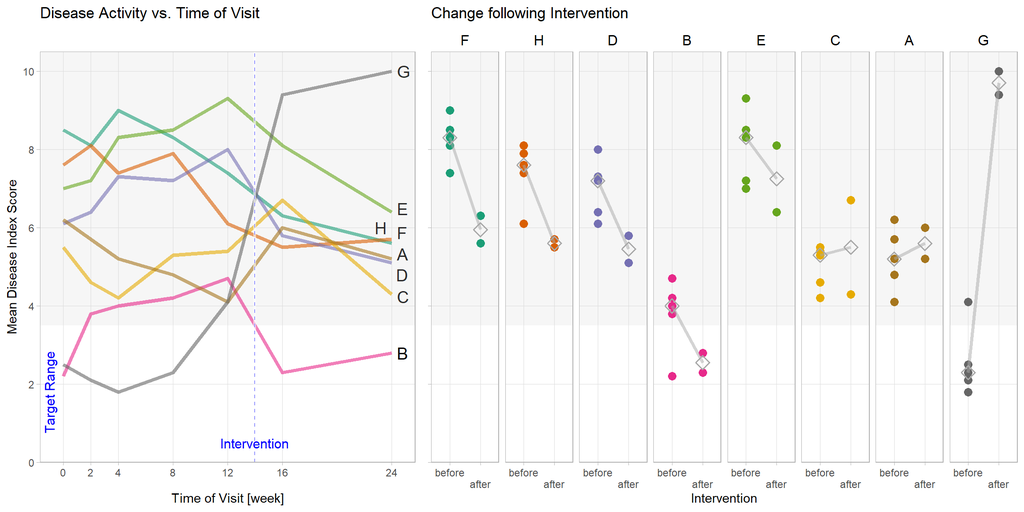

```r
# - Chunk_2                                                                             - #
# - Requires R-libraries (r libraries and data) and object exampleData_int (chunk_1) - #


## Additional parameters, not supplied with the challenge

# Intervals at which visits 1-7 took place (e.g. weeks)
visitIntervals <- c(0, 2, 4, 8, 12, 16, 24)
interventionTime <- mean (c(visitIntervals[5], visitIntervals[6]))

# Clinically meaningful target for mean disease index score
diseaseScore_target <- 3.5


## Plot

exampleData_int <-
  exampleData_int %>%
  mutate(
    Time_of_visits = rep(visitIntervals, 8)
    )

p_visits <-
  exampleData_int %>%
  mutate(facet_strip = "") %>%   # Empty facet label for aligning the y-axis scales of the two subplots
    ggplot(
    aes(
      x = Time_of_visits,
      y = Mean_Disease_Index,
      color = Treatment
      )
    ) +
  scale_color_brewer(palette="Dark2") +
  geom_text_repel(
    data = subset(
      exampleData_int,
      Time_of_visits ==
        max(visitIntervals) & (Treatment %in% LETTERS[1:8]
        )
      ),
    aes(label = Treatment),
    nudge_x = 0.5,
    color = "black",
    size = 5
  ) +
  annotate(
    "rect",
    xmin = -Inf, xmax = Inf,
    ymin = diseaseScore_target, ymax=Inf,
    fill="lightgrey", alpha=0.2) +
    facet_grid(.
      ~ facet_strip
      ) +
  geom_line (lwd = 1.5, alpha = 0.6) +
  scale_x_continuous(
    breaks = visitIntervals,
    minor_breaks = NULL,
    expand = c(0, 0),
    limits =
      range(visitIntervals) +
      max(visitIntervals)/14 * c(-1, 1),
    labels = c(
      visitIntervals[1:6], paste0(visitIntervals[7],"\n") )
      ) +
  scale_y_continuous(
    breaks = seq(0, 10, 2),
    minor_breaks = NULL,
    expand = c(0, 0), limits = c(0, 10.5)
    ) +
  geom_vline(
    aes(xintercept = interventionTime ),
    linetype = "dashed",
    col = "blue"
    ) +
  annotate(
    "text",
    x = 0.67 - max(visitIntervals)/14,
    y = 1.8,
    label = "Target Range",
    size = 4,
    angle = 90,
    color = "blue"
    ) +
  annotate(
    "rect",
    xmin = interventionTime - 0.1,
    xmax = interventionTime + 0.1,
    ymin = -Inf, ymax=Inf,
    fill="white", alpha=0.6) +
  annotate(
    "text",
    x = interventionTime,
    y = 0.5,
    label = "Intervention",
    size = 4,
    color = "blue"
    ) +
  theme_light() +
  theme(
    legend.position = "none",
    strip.background = element_blank(),
    strip.text.x=element_text(
      colour="black",
      size = 12
      ),
    ) +
  labs(
    y = "Mean Disease Index Score",
    x = "Time of Visit [week]",
    title = "Disease Activity vs. Time of Visit",
    vjust = -0.1
    )


p_intervention <-
  exampleData_int %>%
  ggplot(
    aes(
      x = Intervention,
      y = Mean_Disease_Index,
      color = Treatment,
      )
    ) +
  scale_color_brewer(palette="Dark2") +
  annotate(
    "rect",
    xmin = -Inf, xmax = Inf,
    ymin = 3.5, ymax=Inf,
    fill="lightgrey", alpha=0.2) +
  scale_y_continuous(                  # Same for both subplots
    breaks = seq(0, 10, 2),
    minor_breaks = NULL,
    expand = c(0, 0),
    limits = c(0, 10.5)
    ) +
  scale_x_discrete(
    labels = c("before", "\nafter")
    )+
  facet_grid(.
      ~ Treatment
      ) +
  geom_point(
    size = 3
    ) +
  stat_summary(
    fun = median,
    shape = 5,
    size = 0.8,
    color = "darkgrey"
    ) +
  stat_summary(
    fun = median,
    group = 1,
    geom = "path",
    color = "darkgrey", alpha = 0.5,
    lwd = 1.3
    ) +
  theme_light() +
  theme(
    axis.title.y = element_blank(),
    axis.text.y = element_blank(),
    strip.background = element_blank(),
    strip.text.x=element_text(
      colour="black",
      size = 12
      ),
    legend.position = "none"
    ) +
  labs(
    title = "Change following Intervention",
    vjust = -0.1
    )

ggarrange(
   p_visits,
   p_intervention,
   ncol = 2,
   widths = c(0.7, 1)
   )
```

My second additional parameter were the intervals at which the visits were scheduled. This should give a better impression of the variability of the disease index over time, in particular if the visits were not evenly spaced.

### 3. Final notes

My difficulty with this task was understanding the data, and what messages the figure should convey. It was not clear whether the treatment and/or intervention had a meaningful effect, except for the worsening of disease in group “G”.

Was the “intervention” given between visits 5 and 6 the initiation of treatments A-H? Or were these treatments started before the first visit, followed by an additional intervention that was identical for all groups? If treatments were initiated between visits 5 and 6, and mean disease indices at prior visits represented the baselines for supposedly randomised groups, their large variability should be a concern. Alternatively, the study could have been undertaken to assess the effect of a common intervention in patients on different treatments. However, there were no suggestions of this in the supplied data and “bad” figure.

Redrawing the figure was further limited by having only basic summary data as a source, i.e., mean scores without even margins of error. I therefore compared the medians of those means before and after “intervention” although this is probably an inappropriate method.  
Far better would have been an analysis of covariance <sup>1</sup>. However, this would have required patient-level data.

### 4. References

1. [Statistics notes: Analysing controlled trials with baseline and follow up measurements.](https://doi.org/10.1136/bmj.323.7321.1123)  
   Vickers AJ, Altman DG. BMJ. 2001 Nov 10;323(7321):1123-4.
2. … more bad chards

[figure not shown]

[figure not shown]